# LSI36001 Clinical Data Mining - Project exam

## Milla Kortelainen, 014896653

### 1. Clinical consepts

1. What is standard-of-care in treating HGSOC patients?

#### Standard-of-care for high-grade serous ovarian cancer (HGSOC) patients is surgery where the the effected tissue and tumors are removed, uterus and ovaries in worst case. In addition to surgey chemotherapy, hormone therapy, targeted therapy or immunotherapy can be applied.

2. What do the terms PFI, PFS and OS mean in the context of cancer survival? In what situations would you prefer to use them over RECIST primary therapy outcomes?

#### PFI means progression-free interval, PFS means progression-free survival and OS means overall survival. Progression-free refers to state where patient has resieved treatment for the cancer and after that the cancer hasn’t gotten worse i.e. patient lives with the disease but the disease is not spreading or otherwise incresing. Interval refers to some time interval which has been progression-free and survival is a measurement of time that patient has been progression-free. Overall survival mesures how many patients survive a time perioid when the cause of death is not known, it may be the illness or some other cause.

#### RECIST (Response Evaluation Critera in Solid Tumors) can not be always used because the cancer tumors are not always measurable as it is in ovarian cancer. In cases where the tumors can’t be measured the PFI, PFS and OS can be used to measure primary therapy outcomes.

3. What is the difference between PDS and NACT patients?

#### Difference between PDS and NACT patients is that they are receiving different treatment. PDS patients receive a surgery (as PDS stands for primary debulking surgery) and NACT patients receive chemotherapy (NACT stands for neoadjuvant chemotherapy).

4. To what purpose CA-125 protein is used for in HGSOC? What are its good and bad features?
5. How many CA-125 values KELIM needs for accurate prognosis?

### 2. Experimental design concepts.

Assume you belong to a research group that wants to collect a prospective cohort HGSOC patients. Due to secondary law induced complications, your research group collects patients from one hospital only, which treats ~20% of the HGSOC patients in Finland.

1. How many cases approximately can be collected in the next five years? How many PDS patients do you expect to collect?
2. What are the main obstacles in collecting a dataset for complete medical histories of the HGSOC patient for the next five years?
3. How would you use machine learning in mining medical records written in natural language?
4. Give a brief example how supervised learning could be used to predict HGSOC patient’s response to chemotherapy

| As a training data set a labeled data set would be given for the SL model. Values could be the amount of chemotherapy and PFS would be the filtering value. |
| --- |

### 3. Clinical data mining.

Assume that the research group you belong to is interested in the predictive value of CA-125 measurements in high-grade serous ovarian cancer (HGSOC). The research group has collected prospectively CA-125 values and clinical data from a cohort of HGSOC patients who received primary debulking surgery followed by platinum-taxane chemotherapy.

You are told that the current state-of-the-art method is KELIM (You et al. Gynecologic Oncology 2013). Your mission is to conduct data analysis and answer the research objective **“Are CA-125 values predictive of HGSOC patient response to chemotherapy or overall survival?”** To establish the (possible) link between CA-125 values and patient outcomes you have two options:

1. Make a histogram of the number of measured CA-125 values. How many CA-125 values a median patient has?

```r
library(xlsx)
library(tidyverse)
dataLong <- read.xlsx("longitudinal.xlsx",sheetIndex=1)
dataCV <- read.xlsx("clinical_variables.xlsx", sheetIndex = 1)
```

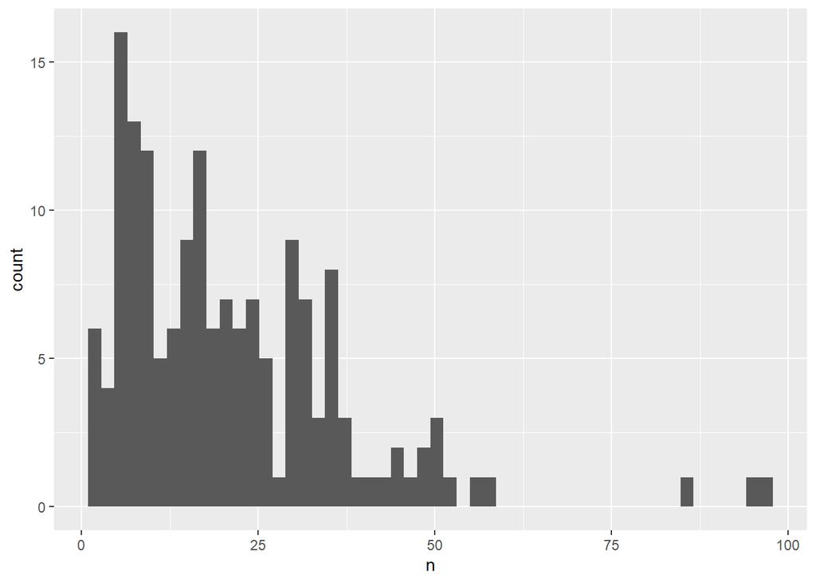

```r
n_of_CA <- dataLong%>% group_by(patient_id)%>%count()
ggplot(n_of_CA,aes(n))+geom_histogram(bins=length(unique(n_of_CA$n)))
```

```r
nrow(dataLong[dataLong$patient_id == dataLong[nrow(dataLong)/2+1,]$patient_id,])
```

```
## [1] 27
```

```r
nrow(dataLong[dataCV$patient_id == dataCV[nrow(dataCV)/2+1,]$patient_id,])
```

```
## [1] 21
```

2. Make a box plot of the CA-125 values. What is dynamic range and median of the CA-125 values?

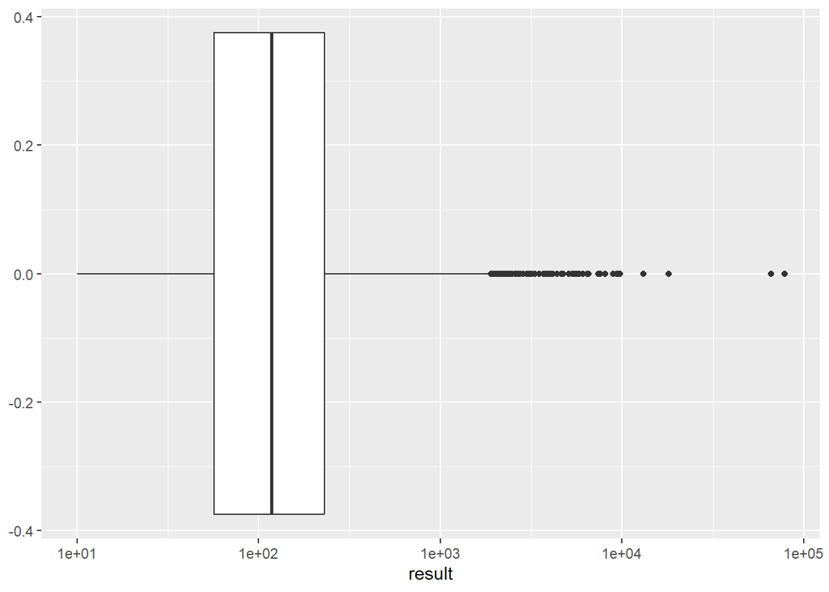

```r
ggplot(dataLong, aes(x=result))+geom_boxplot()+scale_x_log10()
```

```r
sort(dataLong$result)[length(dataLong$result)]/sort(dataLong$result)[1]
```

```
## [1] 7821.7
```

```r
sort(dataLong$result)[length(dataLong$result)/2]
```

```
## [1] 118
```

3. How many patients are eligible to the analysis approach you have chosen?

CA-125 KELIM™ is calculated with minimum 3 CA-125 values measured within the first 100 days (or less) after chemotherapy start. This model does not apply in patients treated in recurrent setting.

```r
n_of_CA[n_of_CA$n>2,]
```

| patient_id | n |
| --- | --- |
| 2016 | 32 |
| 2021 | 17 |
| 2031 | 23 |
| 2049 | 25 |
| 2082 | 29 |
| 2083 | 44 |
| 2094 | 26 |
| 2107 | 9 |
| 2111 | 14 |
| 2118 | 21 |

[output cut: 146 more lines]

```r
library(grid)
n_hundredday_treatment <- dataLong[dataLong$date_relative>=0 & dataLong$date_relative<=100,]%>% group_by(patient_id)%>%count()
n_hundredday_treatment <- n_hundredday_treatment[n_hundredday_treatment$n >=3,]
n <- sum(n_hundredday_treatment$n)
patients <- rep(0,n)
results <- rep(0,n)
time <- rep(0,n)
i<-1
for (id in n_hundredday_treatment$patient_id) {
#id <- n_hundredday_treatment$patient_id[2]
  subset <- dataLong[dataLong$patient_id==id & dataLong$date_relative>=0 & dataLong$date_relative<=100,]
  m <- nrow(subset)
  patients[i:(i+m-1)] <- id
  results[i:(i+m-1)] <- subset$result
  time[i:(i+m-1)] <- subset$date_relative
  i <- i+m
}
patient_values_df <- data.frame(id = patients, result = results, relative_date = time)
```

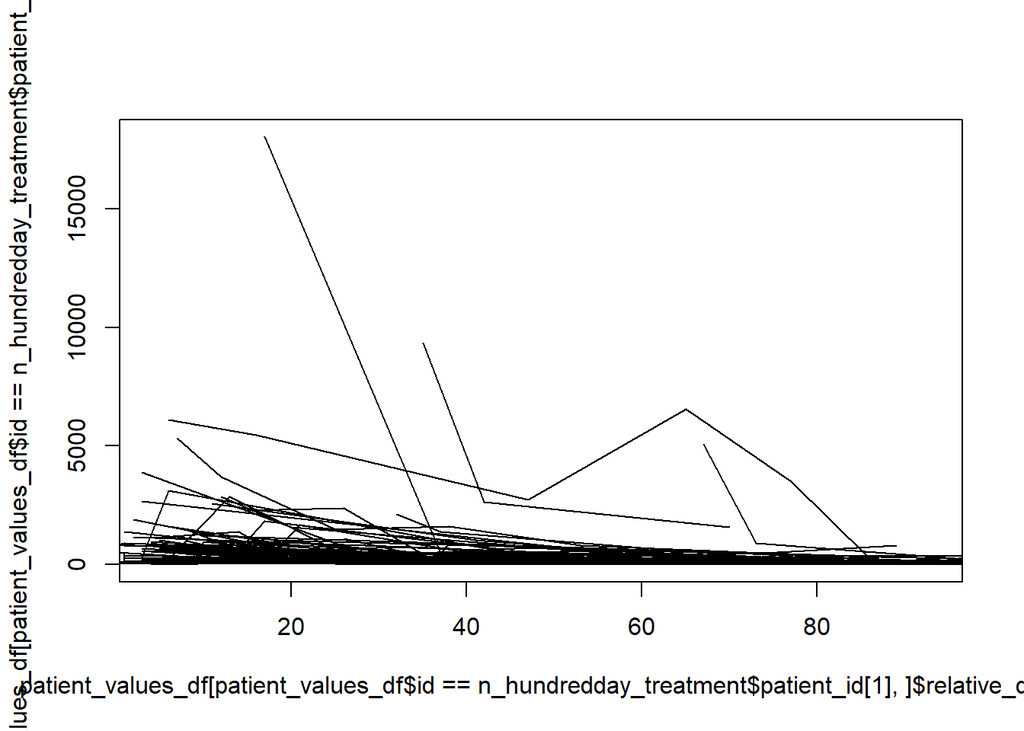

```r
plot(x = patient_values_df[patient_values_df$id == n_hundredday_treatment$patient_id[1],]$relative_date, y = patient_values_df[patient_values_df$id == n_hundredday_treatment$patient_id[1],]$result, type='l', ylim=c(0,max(patient_values_df$result)))
for (id in n_hundredday_treatment$patient_id[2:length(n_hundredday_treatment$patient_id)]) {
  subset <- patient_values_df[patient_values_df$id == id,]
  ordered_subset = subset[order(subset$relative_date),]
  lines(x = ordered_subset$relative_date, y = ordered_subset$result)
}
```

```r
lambda <- 0.25
patient_values_df$corrected_results <- (patient_values_df$result^(lambda)-1)/lambda
patient_values_df
```

| id | result | relative_date | corrected_results |
| --- | --- | --- | --- |
| 2016 | 17 | 4 | 4.122173 |
| 2016 | 186 | 33 | 10.771964 |
| 2016 | 98 | 45 | 8.585385 |
| 2016 | 161 | 65 | 10.248412 |
| 2016 | 22 | 93 | 4.662947 |
| 2021 | 122 | 25 | 9.293825 |
| 2021 | 77 | 13 | 7.849027 |
| 2021 | 22 | 34 | 4.662947 |
| 2021 | 17 | 75 | 4.122173 |
| 2031 | 180 | 31 | 10.651366 |

[output cut: 614 more lines]

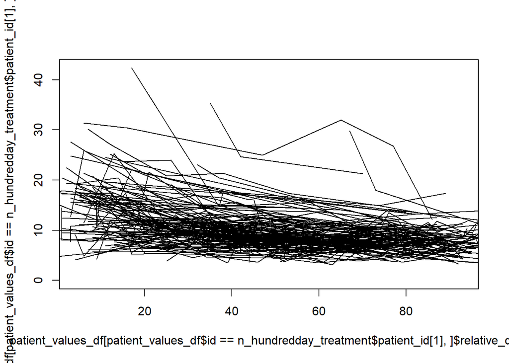

```r
plot(x = patient_values_df[patient_values_df$id == n_hundredday_treatment$patient_id[1],]$relative_date, y = patient_values_df[patient_values_df$id == n_hundredday_treatment$patient_id[1],]$corrected_results, type='l', ylim=c(0,max(patient_values_df$corrected_results)))
for (id in n_hundredday_treatment$patient_id[2:length(n_hundredday_treatment$patient_id)]) {
  subset = patient_values_df[patient_values_df$id == id,]
  ordered_subset = subset[order(subset$relative_date),]
  lines(x = ordered_subset$relative_date, y = ordered_subset$corrected_results)
}
```

```r
kelim_values <- rep(0, nrow(n_hundredday_treatment))
j <- 1
for (id in n_hundredday_treatment$patient_id) {
  patient <- patient_values_df[patient_values_df$id == id,]
  patient <- patient[order(patient$relative_date),]
  total_days <- max(patient$relative_date)-min(patient$relative_date)
  values <- rep(0, nrow(patient)-1)
  for (i in c(2:nrow((patient)))) {
    values[(i-1)] <- (patient$corrected_results[i]-patient$corrected_results[(i-1)])/((patient$relative_date[i]+1)-patient$relative_date[(i-1)])*((patient$relative_date[i]+1)-patient$relative_date[(i-1)])
  }
  kelim_values[j] <- sum(values)/total_days
  j <- j+1
}
n_hundredday_treatment$kelim <- kelim_values
n_hundredday_treatment
```

| patient_id | n | kelim |
| --- | --- | --- |
| 2016 | 5 | 0.0060761162 |
| 2021 | 4 | -0.0601105453 |
| 2031 | 4 | -0.0638893855 |
| 2049 | 5 | -0.0052939501 |
| 2082 | 6 | -0.0195731574 |
| 2083 | 3 | -0.4024147619 |
| 2094 | 7 | -0.0107237330 |
| 2107 | 4 | -0.0910097937 |
| 2111 | 3 | -0.0639626671 |
| 2118 | 4 | -0.0573854141 |

[output cut: 126 more lines]

```r
b <-dataCV[dataCV$patient_id %in% n_hundredday_treatment$patient_id,]
ordered_b <- b[order(b$patient_id),]
ordered_b
```

|  | patient_id | age_at_diagnosis | platinum_free_interval | days_to_progression | days_to_death |
| --- | --- | --- | --- | --- | --- |
| 135 | 2016 | 68 | NA | NA | NA |
| 120 | 2021 | 70 | 437 | 596 | NA |
| 28 | 2031 | 53 | NA | NA | NA |
| 92 | 2049 | 61 | NA | NA | NA |
| 131 | 2082 | 61 | NA | NA | NA |
| 62 | 2083 | 68 | 727 | 950 | NA |
| 16 | 2094 | 75 | NA | NA | 2715 |
| 151 | 2107 | 55 | NA | NA | NA |
| 105 | 2111 | 83 | NA | NA | NA |
| 49 | 2118 | 70 | NA | NA | NA |

[output cut: 126 more lines]

```r
finalData <- data.frame(id =  n_hundredday_treatment$patient_id,
                        kelim = n_hundredday_treatment$kelim,
                        age = ordered_b$age_at_diagnosis,
                        pfi = ordered_b$platinum_free_interval,
                        dtp = ordered_b$days_to_progression,
                        dtd = ordered_b$days_to_death)
finalData
```

| id | kelim | age | pfi | dtp | dtd |
| --- | --- | --- | --- | --- | --- |
| 2016 | 0.0060761162 | 68 | NA | NA | NA |
| 2021 | -0.0601105453 | 70 | 437 | 596 | NA |
| 2031 | -0.0638893855 | 53 | NA | NA | NA |
| 2049 | -0.0052939501 | 61 | NA | NA | NA |
| 2082 | -0.0195731574 | 61 | NA | NA | NA |
| 2083 | -0.4024147619 | 68 | 727 | 950 | NA |
| 2094 | -0.0107237330 | 75 | NA | NA | 2715 |
| 2107 | -0.0910097937 | 55 | NA | NA | NA |
| 2111 | -0.0639626671 | 83 | NA | NA | NA |
| 2118 | -0.0573854141 | 70 | NA | NA | NA |

[output cut: 126 more lines]

```r
dataCV[dataCV$patient_id==2016,]
```

|  | patient_id | age_at_diagnosis | platinum_free_interval | days_to_progression | days_to_death |
| --- | --- | --- | --- | --- | --- |
| 135 | 2016 | 68 | NA | NA | NA |

```r
model <- lm(dtd ~ kelim, data=finalData)
summary(model)
```

```
##
## Call:
## lm(formula = dtd ~ kelim, data = finalData)
##
## Residuals:
##      Min       1Q   Median       3Q      Max
## -1270.83  -371.65   -81.43   263.81  2358.00
##
## Coefficients:
##             Estimate Std. Error t value Pr(>|t|)
## (Intercept)   1260.4      120.9  10.427 1.52e-14 ***
## kelim          217.8      829.4   0.263    0.794
## ---
## Signif. codes:  0 '***' 0.001 '**' 0.01 '*' 0.05 '.' 0.1 ' ' 1
##
## Residual standard error: 673.8 on 54 degrees of freedom
##   (80 observations deleted due to missingness)
## Multiple R-squared:  0.001275,   Adjusted R-squared:  -0.01722
## F-statistic: 0.06894 on 1 and 54 DF,  p-value: 0.7939
```

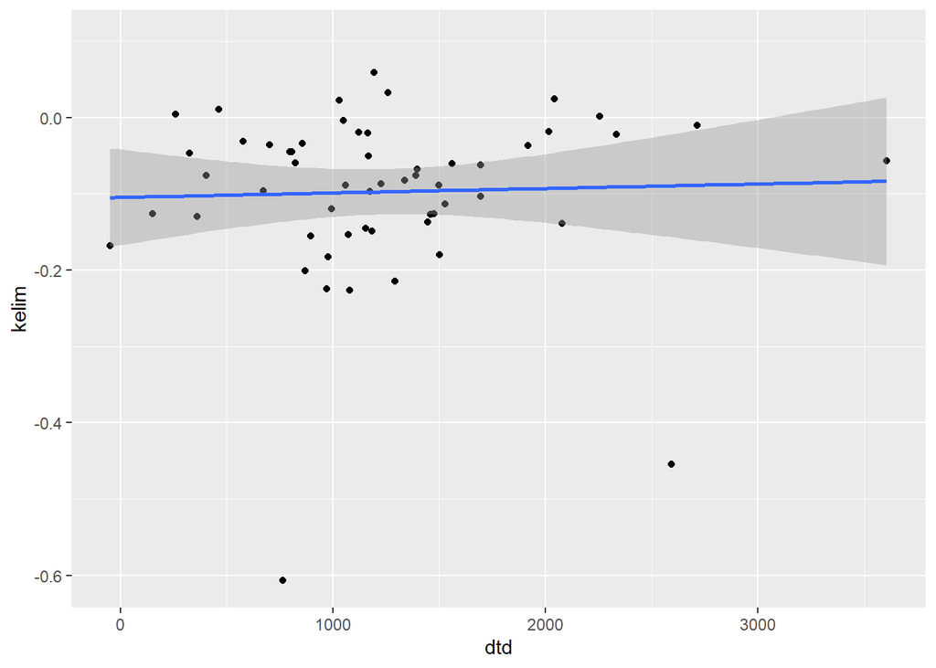

```r
ggplot(finalData, aes(x=dtd, y=kelim)) +geom_point() + geom_smooth(method = "lm")
```

```r
K <- 0.005
BETA <- 0.0046
KPROD <- 20.1
KELIM <- 0.091
A50 <- 0.049
C2 <- 0.5
effect <- 1-C2/(A50+C2)
time1 <- 4
CA1251 <- 4.122173
time2 <- 33
CA1252 <- 10.771964
KPROD*exp(BETA*time2)*effect-KELIM*CA1252 - KPROD*exp(BETA*time1)*effect-KELIM*CA1251
```

```
## [1] -1.094597
```

4. What clinical outcome(s) (as column names in the file clinical_variables.xlsx) would you use in the analysis of i) chemotherapy response and ii) overall survival?

I would use ``pltainium_free_interval` to estimate chemotherapy response and `days_to_death` to estimate overall survival.

```r
dataCV
```

| patient_id | age_at_diagnosis | platinum_free_interval | days_to_progression | days_to_death |
| --- | --- | --- | --- | --- |
| 2830 | 71 | 619 | 621 | 1445 |
| 2547 | 77 | 610 | 752 | NA |
| 2450 | 50 | 65 | 324 | 153 |
| 2701 | 68 | 365 | 731 | 1050 |
| 2564 | 77 | 252 | 532 | 1259 |
| 2418 | 65 | 150 | 446 | 2593 |
| 2809 | 76 | 88 | 438 | 993 |
| 2324 | 58 | 938 | 1093 | NA |
| 2977 | 71 | 90 | 282 | 1031 |
| 2792 | 60 | 600 | 648 | 1155 |

[output cut: 152 more lines]

5. Do the CA-125 values need transformation of any kind before analysis?

6. Justify the criteria you have selected to quantify the predictive value of your approach.

Are CA-125 values predictive of HGSOC patient response to chemotherapy or overall survival?

### 4. Feedback

. State three points that were good and three points for improvement in this course. (Max 2 points)

- I don’t get how the exam measures subjects learned on the course.